# Final Project

First will look at salaries over time.

Note that salary information is only available from 1985 forward.

```r
min(salaries$yearID)
```

```
## [1] 1985
```

We can observe salary trends over time using player salary data from the Lahman dataset, and US household salary data from the US Census Bureau.

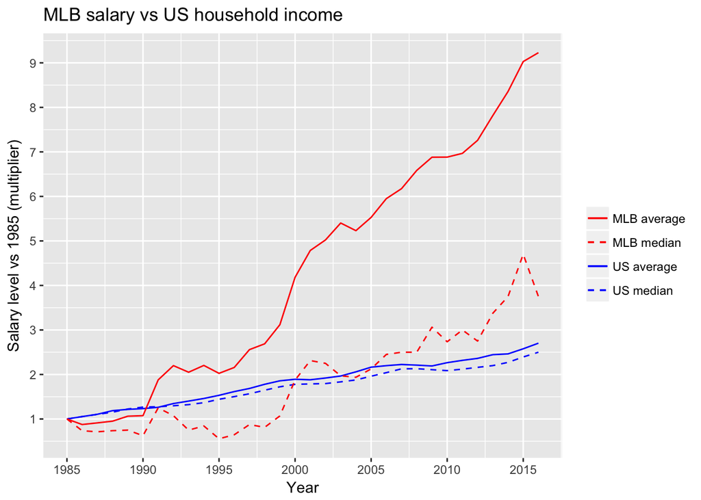

Using the respective 1985 salaries as a baseline, we see that US median household income has increased by around 25% every 5 years. Median player salary growth generally not outpaced the salary growth of US households until the past decade. Average salary, in contrast, has steadily increased since 1990. This suggests that salary trends for “top” players may be different from that of “average” players.

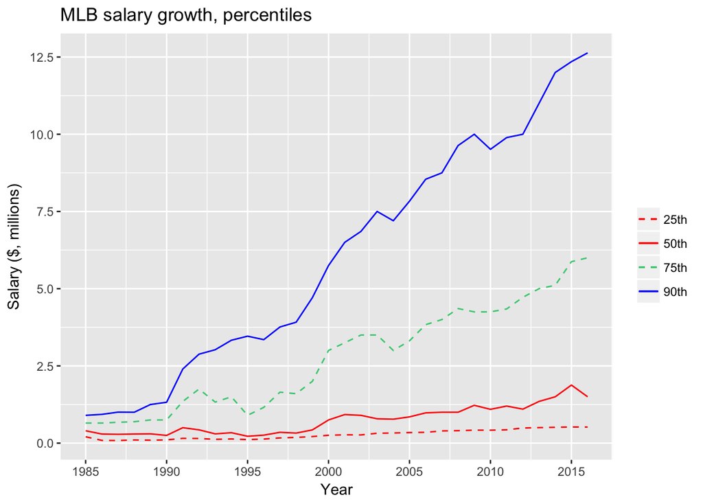

Observing the trends by percentile, we can see that, indeed, salaries have not increased across the board, with large gains for the top paid players, with little change for players in the lower percentiles. We will look at a comparison of percentiles by team.

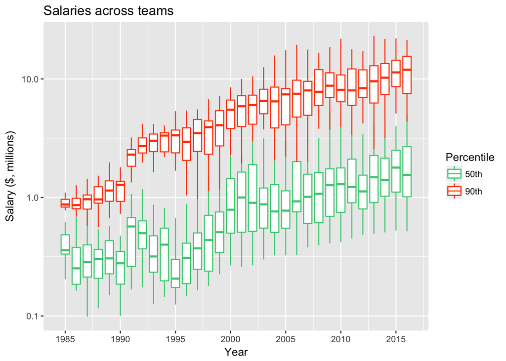

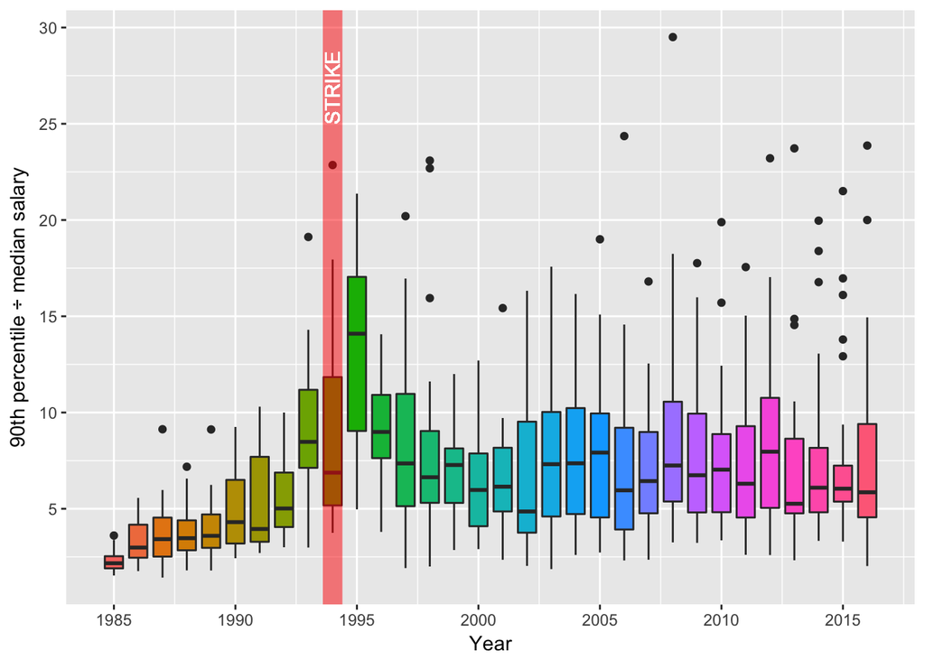

In 1994, two-pronged plan to limit the effect of reduced revenues. First was to enact revenue-sharing in order to keep smaller teams from having to drop out. The other was a salary cap, to limit the labor cost of players. Though the salary thing maybe didn’t go through, revenue sharing did. Was it effective?

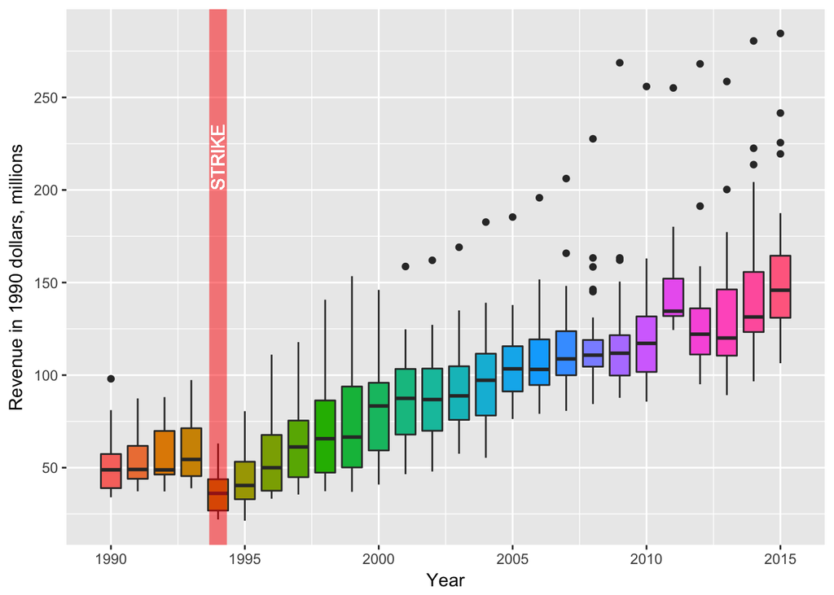

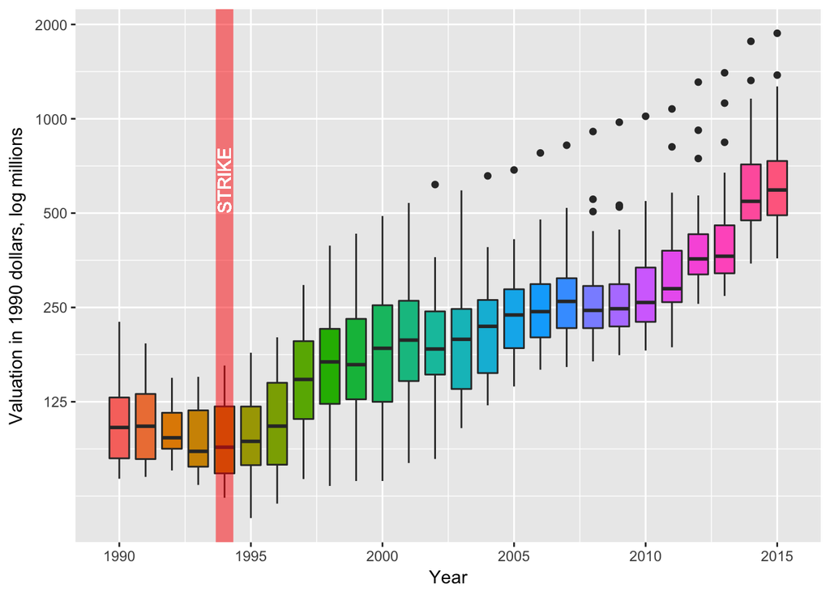

Team valuations rose greatly after the revenue sharing agreement, and again after 2010. Let’s look back at revenues. 2012 valuation data is complete.

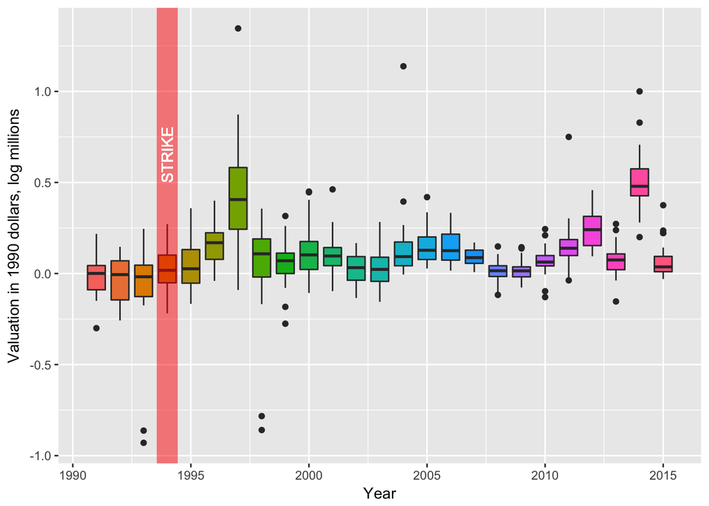

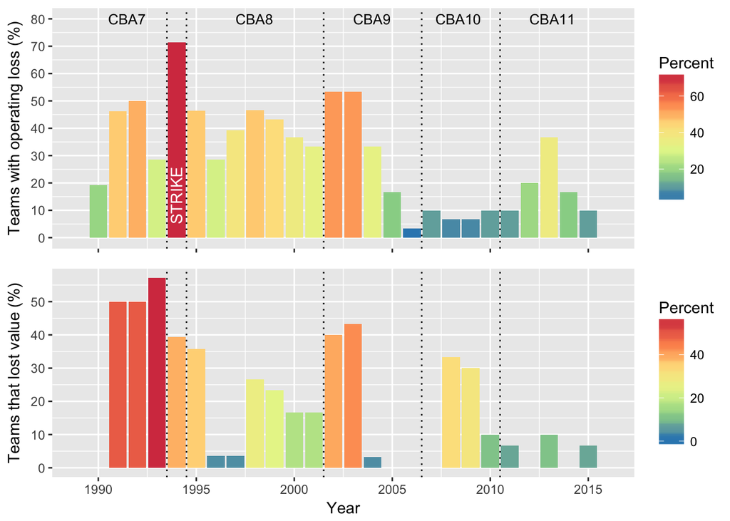

regress/anova by cba?

```r
summary(lm(teams ~ Year,data=oloss))
```

```
##
## Call:
## lm(formula = teams ~ Year, data = oloss)
##
## Residuals:
##      Min       1Q   Median       3Q      Max
## -0.28988 -0.10506  0.01310  0.05647  0.29085
##
## Coefficients:
##              Estimate Std. Error t value Pr(>|t|)
## (Intercept) 29.710471   7.714400   3.851 0.000767 ***
## Year        -0.014688   0.003852  -3.813 0.000845 ***
## ---
## Signif. codes:  0 '***' 0.001 '**' 0.01 '*' 0.05 '.' 0.1 ' ' 1
##
## Residual standard error: 0.1473 on 24 degrees of freedom
## Multiple R-squared:  0.3772, Adjusted R-squared:  0.3513
## F-statistic: 14.54 on 1 and 24 DF,  p-value: 0.0008448
```

```r
summary(lm(teams ~ Year,data=deval))
```

```
##
## Call:
## lm(formula = teams ~ Year, data = deval)
##
## Residuals:
##       Min        1Q    Median        3Q       Max
## -0.279949 -0.084264 -0.006249  0.103421  0.230952
##
## Coefficients:
##              Estimate Std. Error t value Pr(>|t|)
## (Intercept) 32.617231   8.244450   3.956 0.000627 ***
## Year        -0.016183   0.004116  -3.932 0.000666 ***
## ---
## Signif. codes:  0 '***' 0.001 '**' 0.01 '*' 0.05 '.' 0.1 ' ' 1
##
## Residual standard error: 0.1484 on 23 degrees of freedom
## Multiple R-squared:  0.402,  Adjusted R-squared:  0.376
## F-statistic: 15.46 on 1 and 23 DF,  p-value: 0.0006664
```

```r
addcba <- function(df){
  df$cba = .bincode(df$Year,c(0,1993.5,1994.5,2002,2006,2010,10000))
  df$cba = ifelse(df$cba>2,df$cba+5,df$cba)
  df$cba = ifelse(df$cba==1,df$cba+6,df$cba)
  df$cba = ifelse(df$cba==2,NA,df$cba)
  df
}
oloss = addcba(oloss)
deval = addcba(deval)

summary(lm(teams ~ cba,data=oloss))
```

```
##
## Call:
## lm(formula = teams ~ cba, data = oloss)
##
## Residuals:
##      Min       1Q   Median       3Q      Max
## -0.24296 -0.10540  0.01948  0.08193  0.25704
##
## Coefficients:
##             Estimate Std. Error t value Pr(>|t|)
## (Intercept)  0.91430    0.17557   5.208 2.79e-05 ***
## cba         -0.07089    0.01945  -3.645  0.00135 **
## ---
## Signif. codes:  0 '***' 0.001 '**' 0.01 '*' 0.05 '.' 0.1 ' ' 1
##
## Residual standard error: 0.1345 on 23 degrees of freedom
##   (1 observation deleted due to missingness)
## Multiple R-squared:  0.3661, Adjusted R-squared:  0.3385
## F-statistic: 13.28 on 1 and 23 DF,  p-value: 0.001353
```

```r
summary(lm(teams ~ cba,data=deval))
```

```
##
## Call:
## lm(formula = teams ~ cba, data = deval)
##
## Residuals:
##      Min       1Q   Median       3Q      Max
## -0.24066 -0.11041 -0.01111  0.12815  0.23889
##
## Coefficients:
##             Estimate Std. Error t value Pr(>|t|)
## (Intercept)  0.93178    0.20970   4.443 0.000204 ***
## cba         -0.08193    0.02304  -3.556 0.001771 **
## ---
## Signif. codes:  0 '***' 0.001 '**' 0.01 '*' 0.05 '.' 0.1 ' ' 1
##
## Residual standard error: 0.1528 on 22 degrees of freedom
##   (1 observation deleted due to missingness)
## Multiple R-squared:  0.3649, Adjusted R-squared:  0.3361
## F-statistic: 12.64 on 1 and 22 DF,  p-value: 0.001771
```

Measures seem to prevent teams from losing value year-on-year.

https://www.sbnation.com/2010/8/30/1065675/8-30-2002-baseball-avoids-another 2002 - new collective bargaining agreement that increasing rev sharing 70% and added luxury tax

https://www.fangraphs.com/tht/a-history-of-the-collective-bargaining-agreement-part-3/ ^good

So it seems like the measures accomplish the goal of keeping teams on good financial footing. Let’s see how they affect team composition.

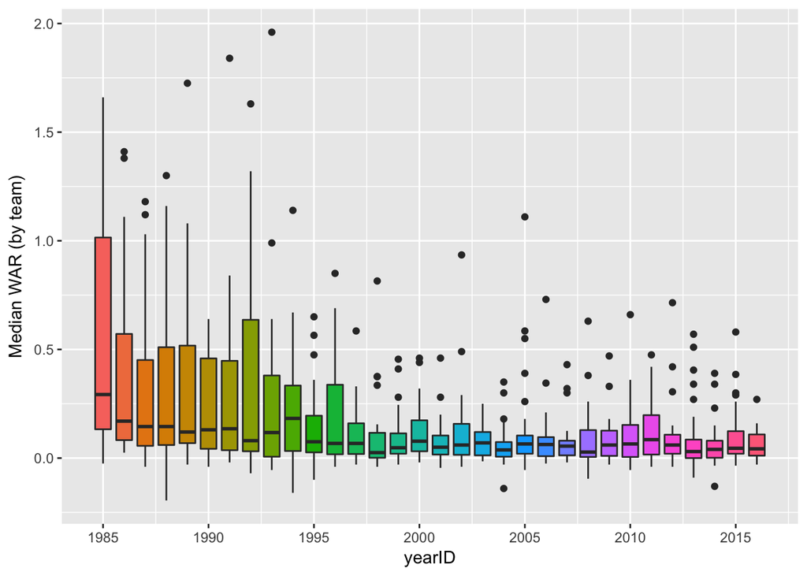

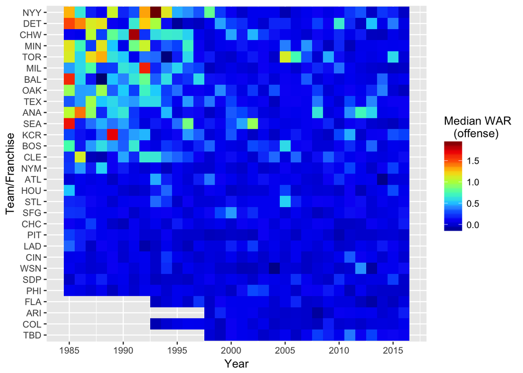

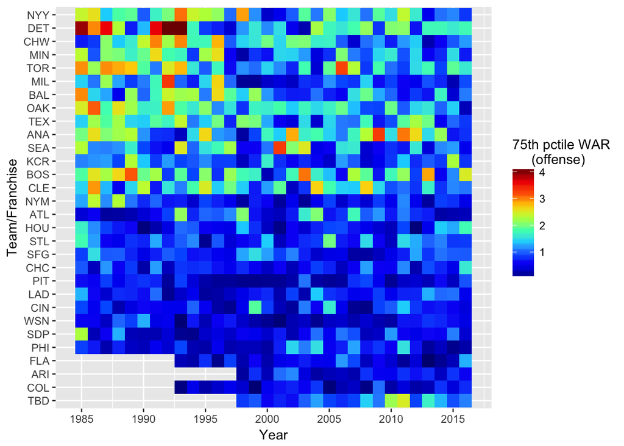

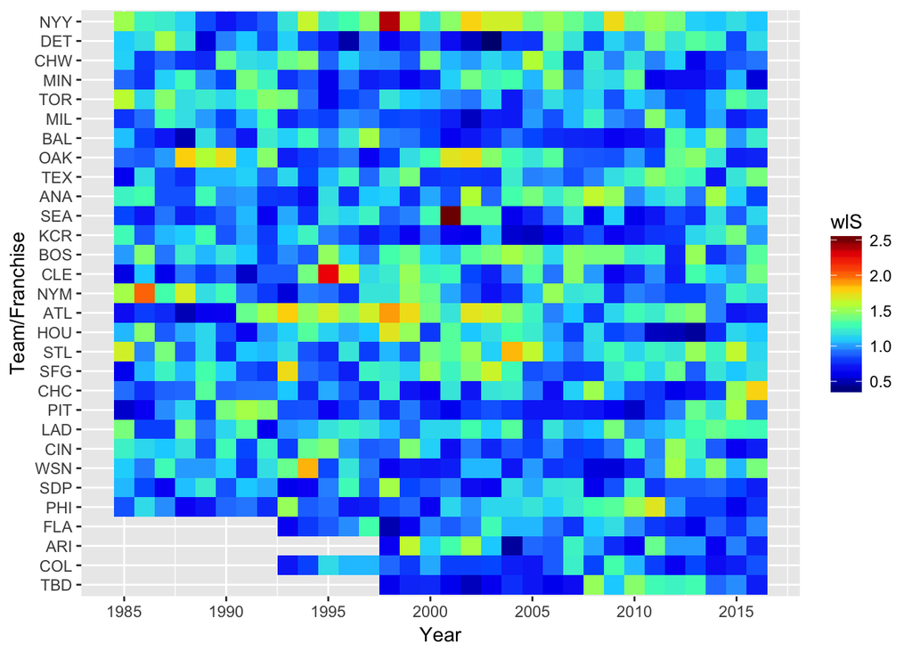

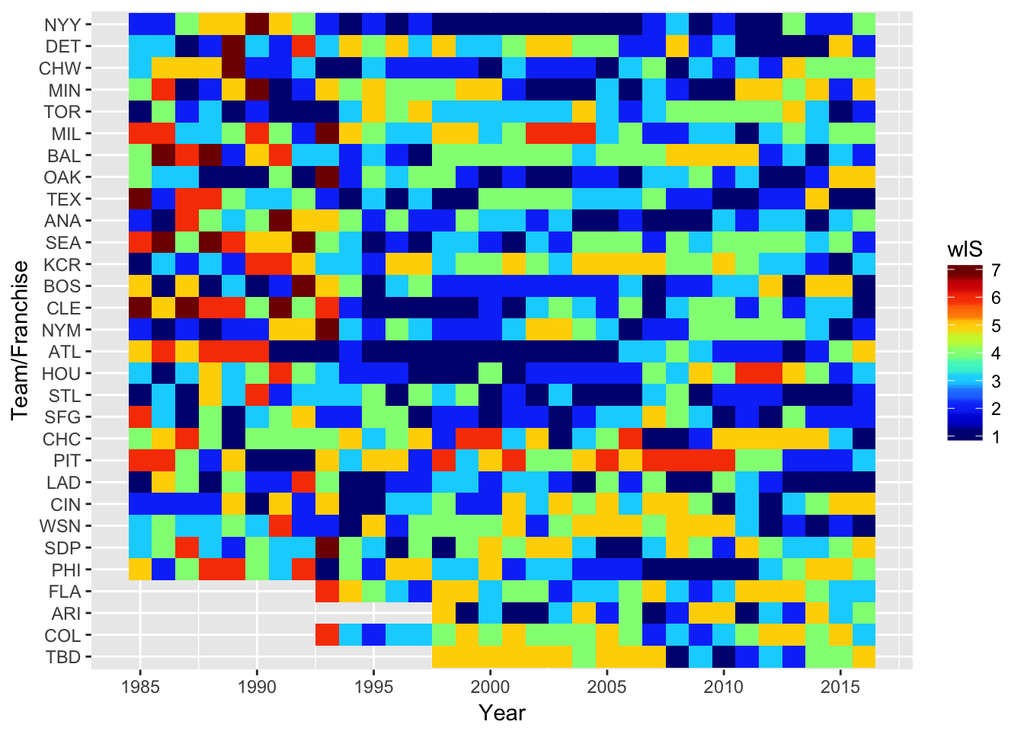

WL ratio and rank were not affected, random as always.

What kind of players were paid more?

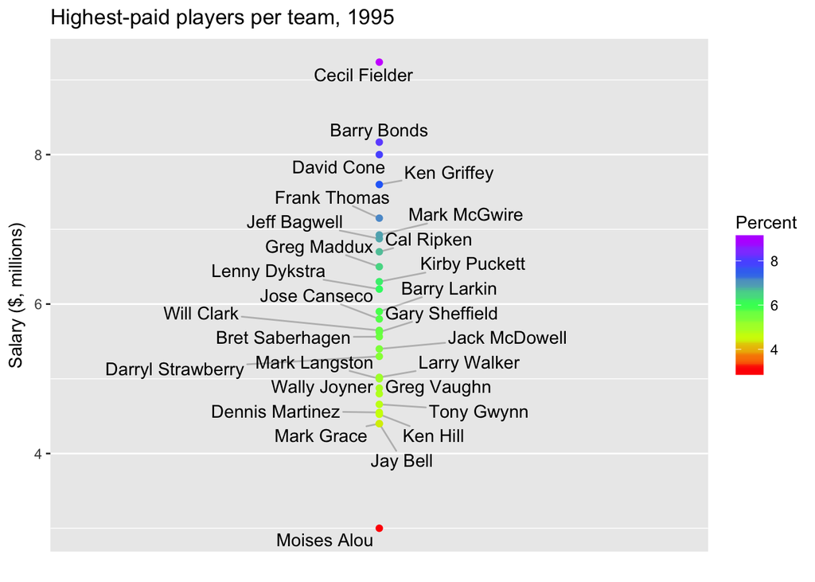

Max salaries in a team went to future Hall of Famers Ken Griffey Jr., Barry Larkin, Kirby Puckett, and Cal Ripken, Jr., as well as other popular players of the time, including Barry Bonds, Jose Canseco, Mark McGwire, and Daryl Strawberry. So, it seems that salaries went to popular players, who were presumably also the players who played well.

Do better players make more?

[figure not shown]

```r
#Previously calculated salary changes and performance changes year-to-year and saved in warplus.csv
warstats <- wars %>% filter(pitcher=="N")
warstats <- warstats[c("playerID","yearID","teamID",
                       "WAA","WAA_off","WAA_def",
                       "WAR","WAR_off","WAR_def",
                       "prevWAA","prevWAA_off","prevWAA_def",
                       "prevWAR","prevWAR_off","prevWAR_def",
                       "dWAA","dWAA_off","dWAA_def",
                       "dWAR","dWAR_off","dWAR_def",
                       "OPS_plus","salary","bump","cut","dsal","pdsal")]
warstats <- warstats %>% filter(yearID > 1985)

warstats <- warstats %>% filter(dsal!=0)
warstats <- warstats %>% filter(abs(dsal)>1)

warzeros <- warstats %>% filter(dsal==0)
warzeros %>% ggplot() + geom_histogram(aes(as.numeric(prevWAA_off)),binwidth=0.05)
```

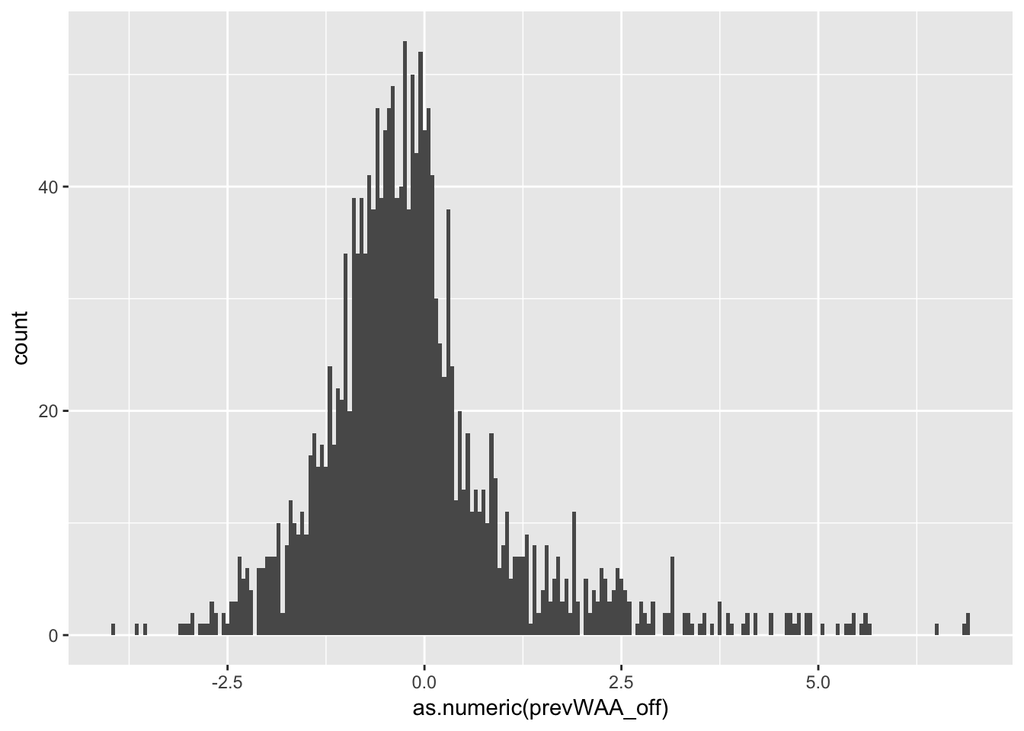

```r
warcut <- warstats %>% filter(dsal<0)
warcut %>% ggplot() + geom_histogram(aes(as.numeric(prevWAA_off)),binwidth=0.05)
```

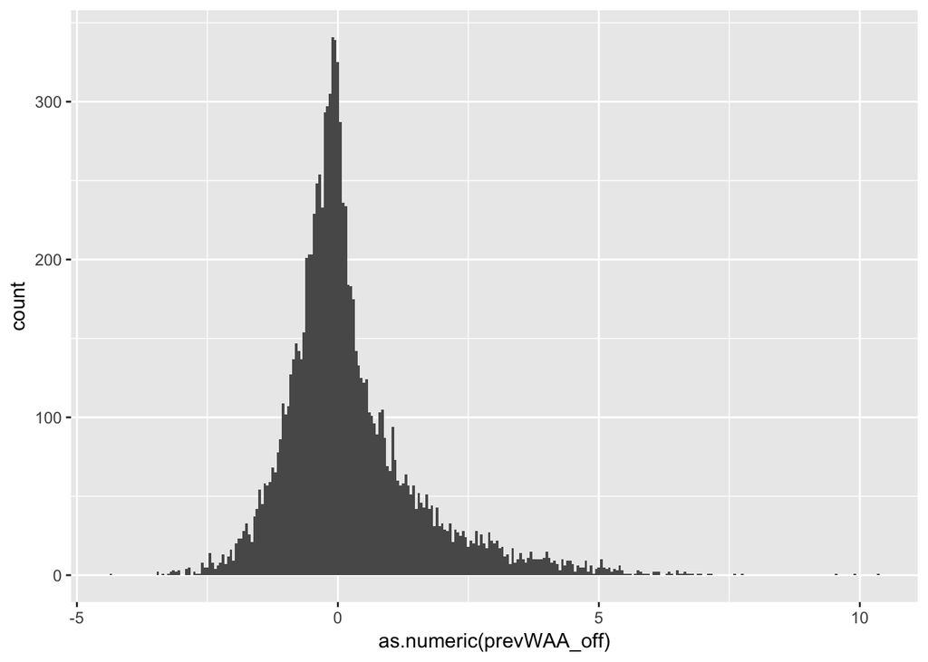

```r
warbump <- warstats %>% filter(dsal>0)
warbump %>% ggplot() + geom_histogram(aes(as.numeric(prevWAA_off)),binwidth=0.05)
```

Doesn’t say much. Let’s look at other trends.

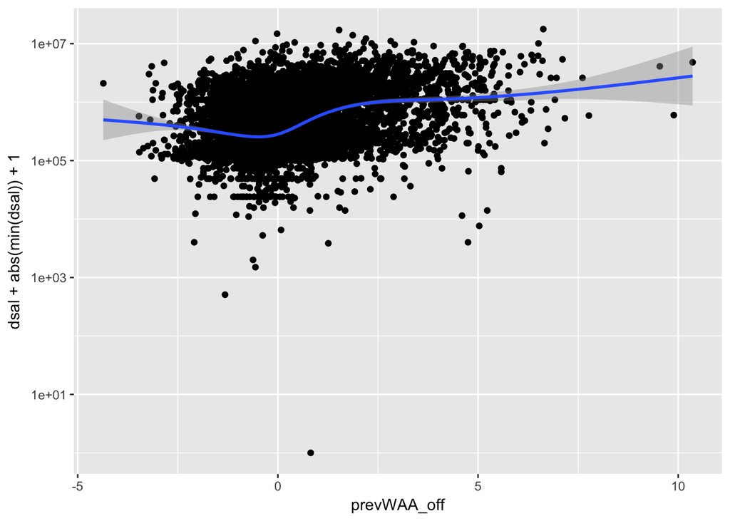

```r
warstats$pdsal[which(warstats$pdsal==Inf)] = NA

warstats %>% filter(pdsal < 40, dsal > -100000) %>% ggplot() +
  geom_point(aes(prevWAA_off,dsal + abs(min(dsal))+1 )) +
  geom_smooth(aes(prevWAA_off,dsal + abs(min(dsal))+1 )) +
  scale_y_continuous(trans="log10")
```

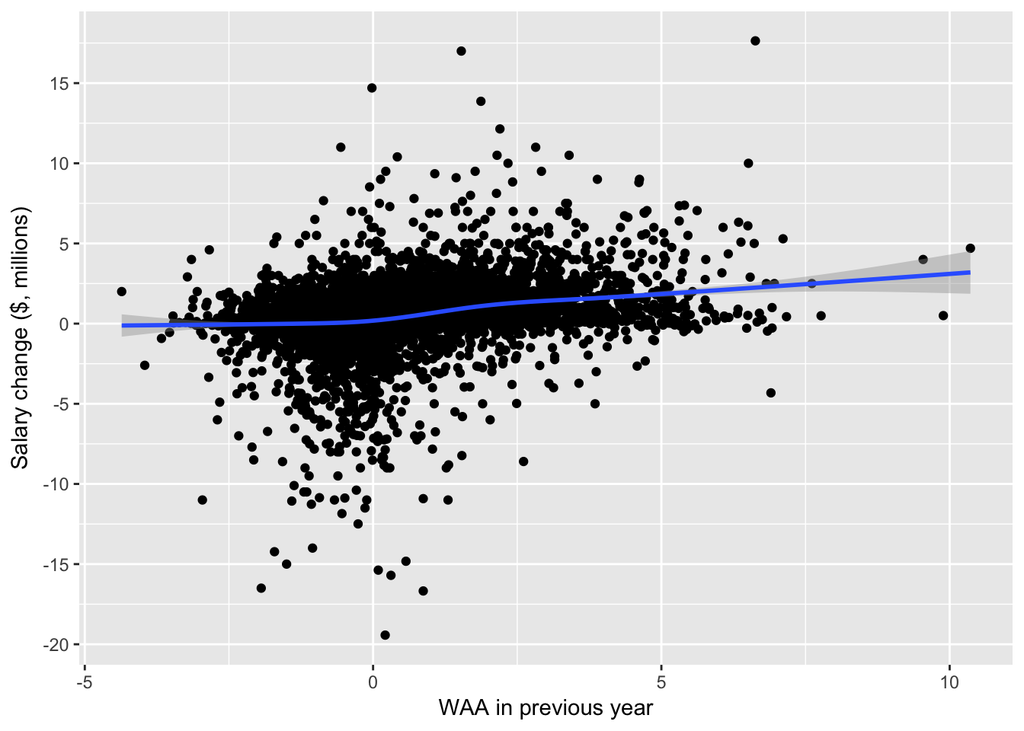

```r
warstats %>% ggplot() +
  geom_point(aes(prevWAA_off,dsal/1000000)) +
  geom_smooth(aes(prevWAA_off,dsal/1000000)) +
  scale_y_continuous(breaks=seq(-30,30,5)) +
  labs(x="WAA in previous year", y="Salary change ($, millions)")
```

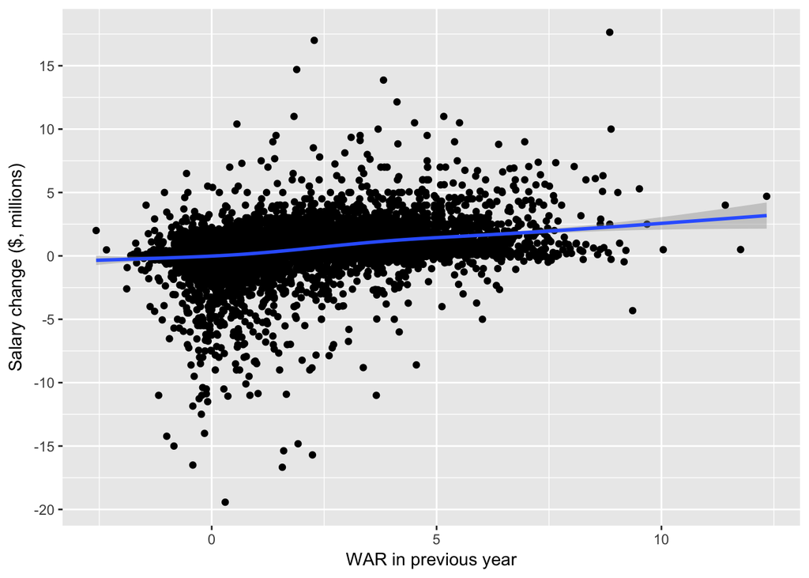

```r
warstats %>% ggplot() +
  geom_point(aes(prevWAR_off,dsal/1000000)) +
  geom_smooth(aes(prevWAR_off,dsal/1000000)) +
  scale_y_continuous(breaks=seq(-30,30,5)) +
  labs(x="WAR in previous year", y="Salary change ($, millions)")
```

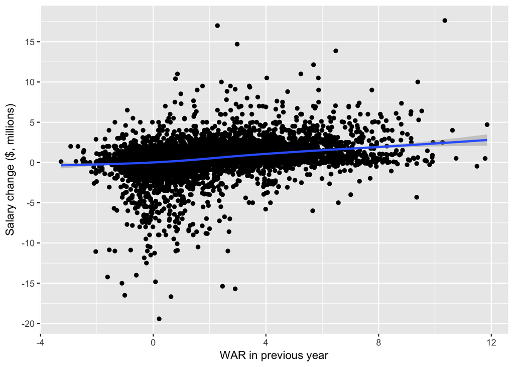

```r
warstats %>% ggplot() +
  geom_point(aes(prevWAR,dsal/1000000)) +
  geom_smooth(aes(prevWAR,dsal/1000000)) +
  scale_y_continuous(breaks=seq(-30,30,5)) +
  labs(x="WAR in previous year", y="Salary change ($, millions)")
```

```r
# warbump %>% filter(pdsal < 10000) %>% ggplot() +
#   scale_y_continuous(trans="log10") +
#   geom_point(aes(as.numeric(prevWAA_off),pdsal))
# warcut %>% filter(pdsal < 10000) %>% ggplot() +
#   geom_point(aes(as.numeric(prevWAA),pdsal))
```

Again, doesn’t look like much. Let’s look at the regression.

```r
w2 <- warstats %>% filter(yearID==1991)
#get est and r^2 by year?
summary(lm(w2$dsal~w2$prevWAA_off))
```

```
##
## Call:
## lm(formula = w2$dsal ~ w2$prevWAA_off)
##
## Residuals:
##      Min       1Q   Median       3Q      Max
## -1242335  -267712  -116604   142628  2142901
##
## Coefficients:
##                Estimate Std. Error t value Pr(>|t|)
## (Intercept)      324225      23463  13.819   <2e-16 ***
## w2$prevWAA_off   165917      18256   9.088   <2e-16 ***
## ---
## Signif. codes:  0 '***' 0.001 '**' 0.01 '*' 0.05 '.' 0.1 ' ' 1
##
## Residual standard error: 435800 on 349 degrees of freedom
## Multiple R-squared:  0.1914, Adjusted R-squared:  0.1891
## F-statistic: 82.59 on 1 and 349 DF,  p-value: < 2.2e-16
```

```r
summary(lm(w2$dsal~w2$prevWAR_off))
```

```
##
## Call:
## lm(formula = w2$dsal ~ w2$prevWAR_off)
##
## Residuals:
##      Min       1Q   Median       3Q      Max
## -1342358  -184112   -66506   103337  1976559
##
## Coefficients:
##                Estimate Std. Error t value Pr(>|t|)
## (Intercept)      133148      27485   4.844 1.91e-06 ***
## w2$prevWAR_off   164169      12931  12.696  < 2e-16 ***
## ---
## Signif. codes:  0 '***' 0.001 '**' 0.01 '*' 0.05 '.' 0.1 ' ' 1
##
## Residual standard error: 400800 on 349 degrees of freedom
## Multiple R-squared:  0.3159, Adjusted R-squared:  0.314
## F-statistic: 161.2 on 1 and 349 DF,  p-value: < 2.2e-16
```

```r
summary(lm(w2$dsal~w2$prevWAR))
```

```
##
## Call:
## lm(formula = w2$dsal ~ w2$prevWAR)
##
## Residuals:
##      Min       1Q   Median       3Q      Max
## -1318664  -198423   -80652    88553  2004829
##
## Coefficients:
##             Estimate Std. Error t value Pr(>|t|)
## (Intercept)   161395      26878   6.005 4.81e-09 ***
## w2$prevWAR    135519      11234  12.063  < 2e-16 ***
## ---
## Signif. codes:  0 '***' 0.001 '**' 0.01 '*' 0.05 '.' 0.1 ' ' 1
##
## Residual standard error: 407100 on 349 degrees of freedom
## Multiple R-squared:  0.2943, Adjusted R-squared:  0.2922
## F-statistic: 145.5 on 1 and 349 DF,  p-value: < 2.2e-16
```

```r
summary(lm(w2$dsal ~ w2$prevWAR + w2$dWAR) )
```

```
##
## Call:
## lm(formula = w2$dsal ~ w2$prevWAR + w2$dWAR)
##
## Residuals:
##      Min       1Q   Median       3Q      Max
## -1273967  -183512   -75252   103165  1839214
##
## Coefficients:
##             Estimate Std. Error t value Pr(>|t|)
## (Intercept)   145008      27543   5.265 2.46e-07 ***
## w2$prevWAR    149332      12539  11.910  < 2e-16 ***
## w2$dWAR        31980      13246   2.414   0.0163 *
## ---
## Signif. codes:  0 '***' 0.001 '**' 0.01 '*' 0.05 '.' 0.1 ' ' 1
##
## Residual standard error: 404300 on 348 degrees of freedom
## Multiple R-squared:  0.3059, Adjusted R-squared:  0.3019
## F-statistic: 76.68 on 2 and 348 DF,  p-value: < 2.2e-16
```

Sure enough, doesn’t look like much. But what if it changes over time?

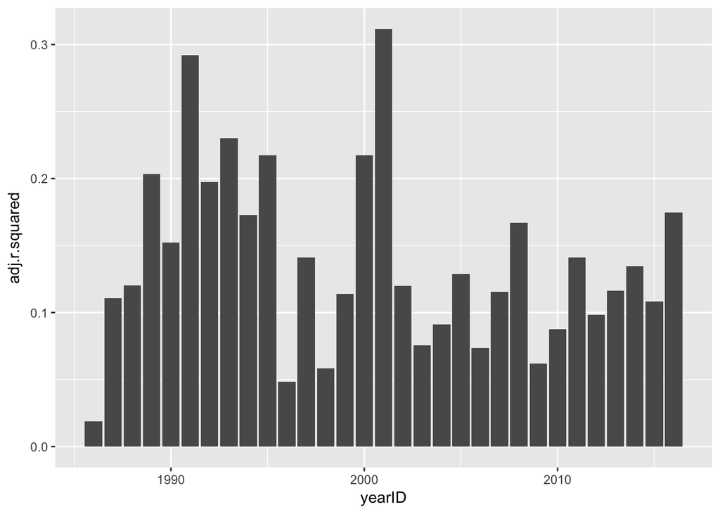

```r
w2 <- warstats

library(broom)
regres <- w2 %>% group_by(yearID) %>% do(glance(lm(dsal ~ prevWAR,data=.)))

regres %>% ggplot() + geom_bar(aes(yearID,adj.r.squared),stat="identity")
```

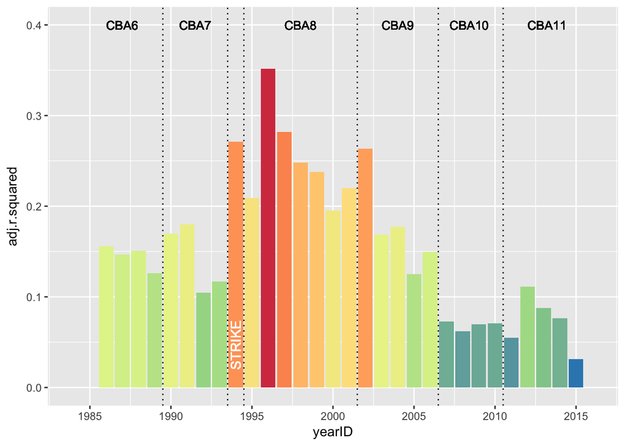

```r
w2 <- warstats

library(broom)
regres <- w2 %>% group_by(yearID) %>% do(glance(lm(salary ~ WAR,data=.)))

regres %>% ggplot() + geom_bar(aes(yearID,adj.r.squared,fill=adj.r.squared),stat="identity") +
    scale_x_continuous(limits = c(1984,2016), breaks=seq(1985,2015,5)) +
    scale_fill_distiller(palette = "Spectral",breaks=seq(0,70,20),name="Percent") +
    geom_text(aes(x=1994,y=0.02),label="STRIKE",angle=90,hjust = 0,color="white") +
    geom_text(aes(x=1986,y=.4),label="CBA6",hjust = 0,color="black",size=3.5) +
    geom_text(aes(x=1990.5,y=.4),label="CBA7",hjust = 0,color="black",size=3.5) +
    geom_text(aes(x=1997,y=.4),label="CBA8",hjust = 0,color="black",size=3.5) +
    geom_text(aes(x=2003,y=.4),label="CBA9",hjust = 0,color="black",size=3.5) +
    geom_text(aes(x=2007.2,y=.4),label="CBA10",hjust = 0,color="black",size=3.5) +
    geom_text(aes(x=2012,y=.4),label="CBA11",hjust = 0,color="black",size=3.5) +
    geom_vline(aes(xintercept=1989.5),linetype=3, color="black") +
    geom_vline(aes(xintercept=1993.5),linetype=3, color="black") +
    geom_vline(aes(xintercept=1994.5),linetype=3, color="black") +
    geom_vline(aes(xintercept=2001.5),linetype=3, color="black") +
    geom_vline(aes(xintercept=2006.5),linetype=3, color="black") +
    geom_vline(aes(xintercept=2010.5),linetype=3, color="black")
```

Looks like this may have changed along with the collective bargaining agreements. May have had to do with luxury tax. Or maybe steroid era.